# S03 T05 Exploració de les dades-JM-Copy4

### Importing libraries

```python
import matplotlib.pyplot as plt
import numpy as np
import os
import pandas as pd
import datetime as dt

pd.set_option("display.max_rows",100)
```

### Consulting path

```python
print(os.listdir(r'C:\Users\jmane\Documents\Data analysis'))
```

```
['DelayedFlights.csv']
```

### Reading the cvs document and creating dataframe

```python
df1 = pd.read_csv(r'C:\Users\jmane\Documents\Data analysis\DelayedFlights.csv', delimiter=',')
df1.dataframeName = 'DelayedFlights.csv'
```

### Getting the data shape

```python
nRow, nCol = df1.shape
print(f'There are {nRow} rows and {nCol} columns')
```

```
There are 1936758 rows and 30 columns
```

#### Its a big data frame with almost 2 milion rows and 30 colums

### Inspecting head and tail of the data frame

```python
df1.head()
```

|  | Unnamed: 0 | Year | Month | DayofMonth | DayOfWeek | DepTime | CRSDepTime | ArrTime | CRSArrTime | UniqueCarrier | ... | TaxiIn | TaxiOut | Cancelled | CancellationCode | Diverted | CarrierDelay | WeatherDelay | NASDelay | SecurityDelay | LateAircraftDelay |
| --- | --- | --- | --- | --- | --- | --- | --- | --- | --- | --- | --- | --- | --- | --- | --- | --- | --- | --- | --- | --- | --- |
| 0 | 0 | 2008 | 1 | 3 | 4 | 2003.0 | 1955 | 2211.0 | 2225 | WN | ... | 4.0 | 8.0 | 0 | N | 0 | NaN | NaN | NaN | NaN | NaN |
| 1 | 1 | 2008 | 1 | 3 | 4 | 754.0 | 735 | 1002.0 | 1000 | WN | ... | 5.0 | 10.0 | 0 | N | 0 | NaN | NaN | NaN | NaN | NaN |
| 2 | 2 | 2008 | 1 | 3 | 4 | 628.0 | 620 | 804.0 | 750 | WN | ... | 3.0 | 17.0 | 0 | N | 0 | NaN | NaN | NaN | NaN | NaN |
| 3 | 4 | 2008 | 1 | 3 | 4 | 1829.0 | 1755 | 1959.0 | 1925 | WN | ... | 3.0 | 10.0 | 0 | N | 0 | 2.0 | 0.0 | 0.0 | 0.0 | 32.0 |
| 4 | 5 | 2008 | 1 | 3 | 4 | 1940.0 | 1915 | 2121.0 | 2110 | WN | ... | 4.0 | 10.0 | 0 | N | 0 | NaN | NaN | NaN | NaN | NaN |

5 rows × 30 columns

```python
df1.tail()
```

|  | Unnamed: 0 | Year | Month | DayofMonth | DayOfWeek | DepTime | CRSDepTime | ArrTime | CRSArrTime | UniqueCarrier | ... | TaxiIn | TaxiOut | Cancelled | CancellationCode | Diverted | CarrierDelay | WeatherDelay | NASDelay | SecurityDelay | LateAircraftDelay |
| --- | --- | --- | --- | --- | --- | --- | --- | --- | --- | --- | --- | --- | --- | --- | --- | --- | --- | --- | --- | --- | --- |
| 1936753 | 7009710 | 2008 | 12 | 13 | 6 | 1250.0 | 1220 | 1617.0 | 1552 | DL | ... | 9.0 | 18.0 | 0 | N | 0 | 3.0 | 0.0 | 0.0 | 0.0 | 22.0 |
| 1936754 | 7009717 | 2008 | 12 | 13 | 6 | 657.0 | 600 | 904.0 | 749 | DL | ... | 15.0 | 34.0 | 0 | N | 0 | 0.0 | 57.0 | 18.0 | 0.0 | 0.0 |
| 1936755 | 7009718 | 2008 | 12 | 13 | 6 | 1007.0 | 847 | 1149.0 | 1010 | DL | ... | 8.0 | 32.0 | 0 | N | 0 | 1.0 | 0.0 | 19.0 | 0.0 | 79.0 |
| 1936756 | 7009726 | 2008 | 12 | 13 | 6 | 1251.0 | 1240 | 1446.0 | 1437 | DL | ... | 13.0 | 13.0 | 0 | N | 0 | NaN | NaN | NaN | NaN | NaN |
| 1936757 | 7009727 | 2008 | 12 | 13 | 6 | 1110.0 | 1103 | 1413.0 | 1418 | DL | ... | 8.0 | 11.0 | 0 | N | 0 | NaN | NaN | NaN | NaN | NaN |

5 rows × 30 columns

### Checking for duplicates

```python
df1.duplicated().sum()
```

```
0
```

### Checking data types

```python
df1.info()
```

```
<class 'pandas.core.frame.DataFrame'>
RangeIndex: 1936758 entries, 0 to 1936757
Data columns (total 30 columns):
 #   Column             Dtype
---  ------             -----
 0   Unnamed: 0         int64
 1   Year               int64
 2   Month              int64
 3   DayofMonth         int64
 4   DayOfWeek          int64
 5   DepTime            float64
 6   CRSDepTime         int64
 7   ArrTime            float64
 8   CRSArrTime         int64
 9   UniqueCarrier      object
```

[output cut: 22 more lines]

### Converting Categorical Variables to object type to save memory

```python
df1[df1.columns[0:4]]=df1[df1.columns[0:4]].astype(object)
df1[df1.columns[8:10]]=df1[df1.columns[8:10]].astype(object)
df1[df1.columns[21:24]]=df1[df1.columns[21:24]].astype(object)
```

### Statistical exploration of numerical colums

```python
print (df1.describe())
```

```
          DayOfWeek       DepTime    CRSDepTime       ArrTime     FlightNum  \
count  1.936758e+06  1.936758e+06  1.936758e+06  1.929648e+06  1.936758e+06
mean   3.984827e+00  1.518534e+03  1.467473e+03  1.610141e+03  2.184263e+03
std    1.995966e+00  4.504853e+02  4.247668e+02  5.481781e+02  1.944702e+03
min    1.000000e+00  1.000000e+00  0.000000e+00  1.000000e+00  1.000000e+00
25%    2.000000e+00  1.203000e+03  1.135000e+03  1.316000e+03  6.100000e+02
50%    4.000000e+00  1.545000e+03  1.510000e+03  1.715000e+03  1.543000e+03
75%    6.000000e+00  1.900000e+03  1.815000e+03  2.030000e+03  3.422000e+03
max    7.000000e+00  2.400000e+03  2.359000e+03  2.400000e+03  9.742000e+03

       ActualElapsedTime  CRSElapsedTime       AirTime      ArrDelay  \
count       1.928371e+06    1.936560e+06  1.928371e+06  1.928371e+06
mean        1.333059e+02    1.343027e+02  1.082771e+02  4.219988e+01
std         7.206007e+01    7.134144e+01  6.864261e+01  5.678472e+01
min         1.400000e+01   -2.500000e+01  0.000000e+00 -1.090000e+02
25%         8.000000e+01    8.200000e+01  5.800000e+01  9.000000e+00
50%         1.160000e+02    1.160000e+02  9.000000e+01  2.400000e+01
75%         1.650000e+02    1.650000e+02  1.370000e+02  5.600000e+01
max         1.114000e+03    6.600000e+02  1.091000e+03  2.461000e+03

           DepDelay      Distance        TaxiIn      Diverted  CarrierDelay  \
count  1.936758e+06  1.936758e+06  1.929648e+06  1.936758e+06  1.247488e+06
mean   4.318518e+01  7.656862e+02  6.812975e+00  4.003598e-03  1.917940e+01
std    5.340250e+01  5.744797e+02  5.273595e+00  6.314722e-02  4.354621e+01
min    6.000000e+00  1.100000e+01  0.000000e+00  0.000000e+00  0.000000e+00
25%    1.200000e+01  3.380000e+02  4.000000e+00  0.000000e+00  0.000000e+00
50%    2.400000e+01  6.060000e+02  6.000000e+00  0.000000e+00  2.000000e+00
75%    5.300000e+01  9.980000e+02  8.000000e+00  0.000000e+00  2.100000e+01
max    2.467000e+03  4.962000e+03  2.400000e+02  1.000000e+00  2.436000e+03

       WeatherDelay      NASDelay  SecurityDelay  LateAircraftDelay
count  1.247488e+06  1.247488e+06   1.247488e+06       1.247488e+06
mean   3.703571e+00  1.502164e+01   9.013714e-02       2.529647e+01
std    2.149290e+01  3.383305e+01   2.022714e+00       4.205486e+01
min    0.000000e+00  0.000000e+00   0.000000e+00       0.000000e+00
25%    0.000000e+00  0.000000e+00   0.000000e+00       0.000000e+00
50%    0.000000e+00  2.000000e+00   0.000000e+00       8.000000e+00
75%    0.000000e+00  1.500000e+01   0.000000e+00       3.300000e+01
max    1.352000e+03  1.357000e+03   3.920000e+02       1.316000e+03
```

### Looking for inconsistent data (negative numbers)

```python
print(all(i < 0 for i in df1['ArrTime']))
print(all(i < 0 for i in df1['CRSArrTime']))
print(all(i < 0 for i in df1['DepTime']))
print(all(i < 0 for i in df1['CRSDepTime']))
```

```
False
False
False
False
```

### Checking for missing values

```python
df1.isna().sum()
```

```
Unnamed: 0                0
Year                      0
Month                     0
DayofMonth                0
DayOfWeek                 0
DepTime                   0
CRSDepTime                0
ArrTime                7110
CRSArrTime                0
UniqueCarrier             0
FlightNum                 0
TailNum                   5
ActualElapsedTime      8387
CRSElapsedTime          198
AirTime                8387
ArrDelay               8387
DepDelay                  0
Origin                    0
Dest                      0
Distance                  0
TaxiIn                 7110
TaxiOut                 455
Cancelled                 0
CancellationCode          0
Diverted                  0
CarrierDelay         689270
WeatherDelay         689270
NASDelay             689270
SecurityDelay        689270
LateAircraftDelay    689270
dtype: int64
```

### Checking for typo errors

```python
num_cols = df1._get_numeric_data().columns
cols = df1.columns
cat_cols = list(set(cols) - set(num_cols))
print (cat_cols)
```

```
['TailNum', 'DayofMonth', 'CancellationCode', 'TaxiOut', 'Origin', 'Dest', 'Unnamed: 0', 'CRSArrTime', 'Month', 'Year', 'Cancelled', 'UniqueCarrier']
```

```python
#Value counts
for col in cat_cols:
    if col in ['DayOfWeek','UniqueCarrier','Month', 'Cancelled','DayofMonth','CancellationCode','Diverted']:
        print((df1[col].value_counts()))
```

```
22    71649
21    70168
1     67815
7     67478
15    65587
27    65374
18    65132
20    65071
19    64470
14    64407
24    64202
10    63385
2     63339
11    63331
23    63320
17    63110
8     62979
4     62682
26    62549
9     62057
6     61814
12    61517
13    61278
16    61152
28    61093
3     60389
5     60000
25    59056
29    56893
30    56721
31    38740
Name: DayofMonth, dtype: int64
N    1936125
B        307
A        246
C         80
Name: CancellationCode, dtype: int64
12    203385
6     200914
3     200842
```

[output cut: 19 more lines]

```
XE    103663
CO    100195
US     98425
EV     81877
NW     79108
FL     71284
YV     67063
B6     55315
OH     52657
9E     51885
AS     39293
F9     28269
HA      7490
AQ       750
Name: UniqueCarrier, dtype: int64
```

### Creating a heat map correlation matrix with Seaborn

```python
import seaborn as sns
```

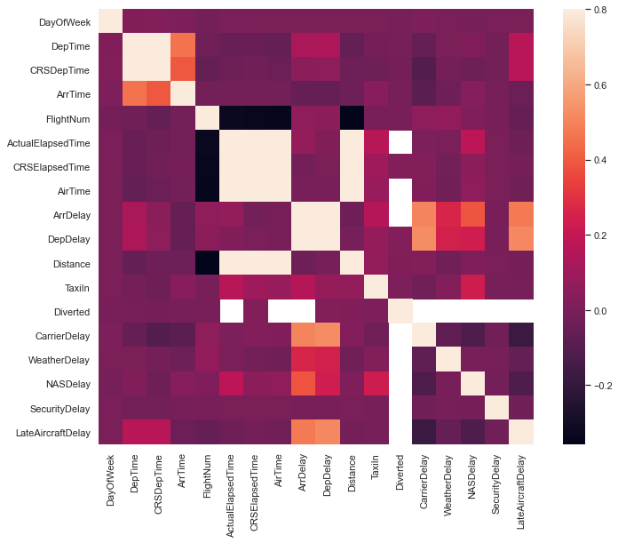

```python
#correlation matrix
corrmat = df1.corr()
f, ax = plt.subplots(figsize=(12, 9))
sns.heatmap(corrmat, vmax=.8, square=True);
plt.show()
```

#### From the heat map que can deduce that there is correlation among different variables, thus we can demonstrate a linear relationship between each other. For exemple, there is a strong correlation between Arribal Delay, Carrier Delay and Later Aircraft Delay.

### Crating a copy of the data frame

```python
temp_df1= df1
```

### Creating a new column "DepDate" with data from other columns

```python
temp_df1['DepDate'] = pd.to_datetime(df1.Year*10000+df1.Month*100+df1.DayofMonth,format='%Y%m%d')
```

```python
temp_df1.loc[0:3,'DepDate']
```

```
0   2008-01-03
1   2008-01-03
2   2008-01-03
3   2008-01-03
Name: DepDate, dtype: datetime64[ns]
```

### Creating a new column "Vel" with data from other columns that calculates miles per hour (mph)

```python
temp_df1['AirTime']=temp_df1['AirTime'].interpolate(method='linear',limit_direction ='both',axis=0) #Interpolation
```

```python
temp_df1['AirTime'].isna().sum()
```

```
0
```

#### No missing values in AirTime after interpolation

```python
temp_df1['AirTime'] = temp_df1['AirTime'].astype("int64")
```

```python
temp_df1['AirTime'].dtype
```

```
dtype('int64')
```

```python
temp_df1['Vel']= temp_df1['Distance'] / (temp_df1['AirTime']/60)
```

```python
print (temp_df1['Vel'])
```

```
0          418.965517
1          430.088496
2          406.578947
3          401.298701
4          474.482759
              ...
1936753    453.000000
1936754    370.000000
1936755    338.852459
1936756    359.325843
1936757    504.230769
Name: Vel, Length: 1936758, dtype: float64
```

```python
pd.set_option('mode.use_inf_as_na', True)
```

```python
df_mean = temp_df1["Vel"].mean()
print (df_mean)
```

```
397.31358150658656
```

#### The averarge velocity was 397 mph

### Deleting columns not needed for our analysis

#### Showing column names to be able to operate more easily on them

```python
temp_df1.columns
```

```
Index(['Unnamed: 0', 'Year', 'Month', 'DayofMonth', 'DayOfWeek', 'DepTime',
       'CRSDepTime', 'ArrTime', 'CRSArrTime', 'UniqueCarrier', 'FlightNum',
       'TailNum', 'ActualElapsedTime', 'CRSElapsedTime', 'AirTime', 'ArrDelay',
       'DepDelay', 'Origin', 'Dest', 'Distance', 'TaxiIn', 'TaxiOut',
       'Cancelled', 'CancellationCode', 'Diverted', 'CarrierDelay',
       'WeatherDelay', 'NASDelay', 'SecurityDelay', 'LateAircraftDelay',
       'DepDate', 'Vel'],
      dtype='object')
```

```python
temp_df1 = temp_df1.drop("Unnamed: 0",1) #Empty
temp_df1 = temp_df1.drop("Year",1) #Converted to date
temp_df1 = temp_df1.drop("CRSDepTime",1)
temp_df1 = temp_df1.drop("CRSElapsedTime",1)
temp_df1 = temp_df1.drop("CRSArrTime",1)
temp_df1 = temp_df1.drop("TailNum",1)
temp_df1 = temp_df1.drop("TaxiIn",1)
temp_df1 = temp_df1.drop("TaxiOut",1)
```

#### Changing names of variables and checking the result

```python
temp_df1['DayOfWeek']=temp_df1['DayOfWeek'].replace([1,2,3,4,5,6,7],["Monday","Tuesday","Wednesday","Thursday","Friday","Saturday","Sunday"])
```

```python
temp_df1['DayOfWeek'].value_counts()
```

```
Friday       323259
Monday       290933
Thursday     289451
Sunday       286111
Wednesday    262805
Tuesday      260943
Saturday     223256
Name: DayOfWeek, dtype: int64
```

### Interpolating missing data

```python
temp_df1['ArrTime']=temp_df1['ArrTime'].interpolate(method='linear',limit_direction ='both',axis=0) #Interploation
temp_df1['ActualElapsedTime']=temp_df1['ActualElapsedTime'].interpolate(method='linear',limit_direction ='both',axis=0) #Interploation
temp_df1['AirTime']=temp_df1['AirTime'].interpolate(method='linear',limit_direction ='both',axis=0) #Interploation
```

### Analysing delays by carrier

#### A flight is counted as "on time" if it operated less than 15 minutes later the scheduled time shown in the carriers' Computerized Reservations Systems (CRS). Arrival Delay is the sum of CarrierDelay, WeatherDelay, NASDelay and LateAircraftDelay. In cases of cancelation or diversion there's no data related to delay causes.

#### Calculating the number of flights by carrier and its share of the market.

```python
flights_num=temp_df1.loc[temp_df1['DepTime']>0, ["UniqueCarrier"]].value_counts()
flights_num2=temp_df1.loc[temp_df1['DepTime']>0, ["UniqueCarrier"]].value_counts(normalize=True)
print (flights_num,"\n\n",flights_num2)
```

```
UniqueCarrier
WN               377602
AA               191865
MQ               141920
UA               141426
OO               132433
DL               114238
XE               103663
CO               100195
US                98425
EV                81877
NW                79108
FL                71284
YV                67063
B6                55315
OH                52657
9E                51885
AS                39293
F9                28269
HA                 7490
AQ                  750
dtype: int64

 UniqueCarrier
WN               0.194966
AA               0.099065
MQ               0.073277
UA               0.073022
OO               0.068379
DL               0.058984
XE               0.053524
CO               0.051733
US               0.050819
EV               0.042275
NW               0.040846
FL               0.036806
YV               0.034626
B6               0.028561
OH               0.027188
9E               0.026790
AS               0.020288
F9               0.014596
HA               0.003867
AQ               0.000387
dtype: float64
```

#### Calculating the number of delayed flights by carrier and its share of the market.

```python
delay=temp_df1.loc[temp_df1['ArrDelay'] >=15, ["UniqueCarrier"]].value_counts()
delay2=delay.sum()
delay3=temp_df1.loc[temp_df1['ArrDelay'] >=15, ["UniqueCarrier"]].value_counts(normalize=True)
print (delay,"\n\n", delay2,"\n\n", delay3)
```

```
UniqueCarrier
WN               203559
AA               132257
MQ                97555
UA                95465
OO                88991
DL                72252
XE                72008
US                59508
CO                58958
EV                56781
NW                54744
YV                50646
FL                46991
OH                39293
B6                38232
9E                35631
AS                24012
F9                15940
HA                 4325
AQ                  340
dtype: int64

 1247488

 UniqueCarrier
WN               0.163175
AA               0.106019
MQ               0.078201
UA               0.076526
OO               0.071336
DL               0.057918
XE               0.057722
US               0.047702
CO               0.047261
EV               0.045516
NW               0.043883
YV               0.040598
FL               0.037668
OH               0.031498
B6               0.030647
9E               0.028562
AS               0.019248
F9               0.012778
HA               0.003467
AQ               0.000273
dtype: float64
```